# 16S DADA2

Input: Illumina-sequenced paired-end fastq files that have been demultiplexed by sample and the barcodes/adapters have been removed.

Output: amplicon sequence variant (ASV) table which is a higher-resolution analogue of the traditional OTU table which recorde the number of times each **exact amplicon sequence variant** was observed in each sample. Taxonomy is then assigned using the SILVA reference database and the data is combined into a phyloseq object.

## Some good resources for understanding the DADA2 pipeline

Our work flow is a mash-up of the following two tutorials:

*Dada2 tutorial* https://benjjneb.github.io/dada2/tutorial.html *Dada2 with Big Data* https://benjjneb.github.io/dada2/bigdata.html

## Starting from Mr. DNA

1. Get the fastq files from [BaseSpace](https://basespace.illumina.com)
2. If the samples are not demultiplexed, i.e. when you downloaded the fastq files from BaseSpace, they came in folders labeled something like “SAM1-53” and within the folder there are two files “SAM1-53.. ..R1_001.fastq.gz” and “SAM1-53.. ..R2_001.fastq.gz,” You will need to demultiplex the samples, one way is by using [MrDNA’s Free software](http://www.mrdnalab.com/mrdnafreesoftware/fastq-processor.html) FastqProcessor. Note that it only runs on a PC, so no Macs. You will also need the metadata files for each sample set. This also removes the barcodes and adapters.
3. Once the samples are demultiplexed (and the barcodes/adapters are also removed), and you have forward and reverse fastq files for each sample, all fastq files need to be in one folder before you start.

## DADA2 to Silva to Phyloseq

### Get things set up

Load the R packages needed.

Set the seed.

```r
set.seed(100)
```

Set path to folder with all fastq files. In this example, we are only working with 3 samples, so 3 forward fastq files and 3 reverse fastq files.

**This is why all fastq files need to be in one folder: you are telling R to look in this folder for your fastqs, if they are not all in this folder, then they will not be used.**

```r
#Path will change for each run
path <- "/Users/Swilliams/Documents/GitHub/microbes_pipeline/Dada2Silva/fastqs"

list.files(path)[1:3] #make sure it worked correctly
```

```
[1] "326.D_S11_L001_R1_001.fa.fastq" "326.D_S11_L001_R2_001.fa.fastq" "327.D_S11_L001_R1_001.fa.fastq"
```

### Filter and Trim Steps

This chunk sets it up so that forward and reverse reads are in the same order and you can get a list of file paths for all samples.

```r
fnRs[1:2]
```

```
[1] "/Users/Swilliams/Documents/GitHub/microbes_pipeline/Dada2Silva/fastqs/326.D_S11_L001_R2_001.fa.fastq"
[2] "/Users/Swilliams/Documents/GitHub/microbes_pipeline/Dada2Silva/fastqs/327.D_S11_L001_R2_001.fa.fastq"
```

#### Plot the quality profiles

Plot the visual summary of the distribution of quality scores as a function of sequence position for the fastq files

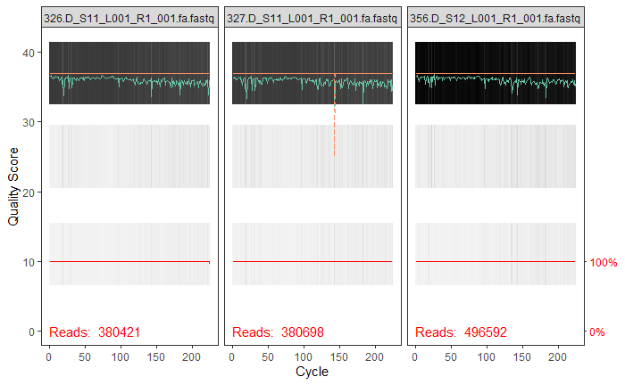

```r
plotQualityProfile(fnFs[1:3])
```

From the tutorial: In gray-scale is a heat map of the frequency of each quality score at each base position. The mean quality score at each position is shown by the green line, and the quartiles of the quality score distribution by the orange lines. The red line shows the scaled proportion of reads that extend to at least that position (this is more useful for other sequencing technologies, as Illumina reads are typically all the same length, hence the flat red line).

Now the reverse reads:

[figure not shown]

```r
plotQualityProfile(fnRs[1:3])
```

#### Interpreting the quality profiles to set the filter and trim step:

The reverse reads aren’t as good quality as the forward reads, which can happen with Illumina sequencing. DADA2 is pretty robust to lower quality sequences. Trimming as the average qualities crash improves the algorithms sensitivity to rate sequence variants.

From the tutorial: *Your reads must still overlap after truncation in order to merge them later!* The tutorial is using 2x250 V4 sequence data, so the forward and reverse reads almost completely overlap and our trimming can be completely guided by the quality scores. If you are using a less-overlapping primer set, like V1-V2 or V3-V4, your truncLen must be large enough to maintain 20 + biological.length.variation nucleotides of overlap between them.

#### The actual filter and trim step

This chunk takes some time to run. It is a computer-time-extensive step. For the 3 example samples, it took my PC ~ 3 minutes to run the ‘filterAndTrim function’ (line 112). So estimate it taking about a minute per sample.

```r
head(out2)
```

```
                               reads.in reads.out
326.D_S11_L001_R1_001.fa.fastq   380421    352785
327.D_S11_L001_R1_001.fa.fastq   380698    348760
356.D_S12_L001_R1_001.fa.fastq   496592    460160
```

```r
colSums(out2)[2]/colSums(out2)[1]
```

```
reads.out
0.9236661
```

#### Estimate errors

This step takes a very very long time. Set multithread=TRUE when working on a mac.

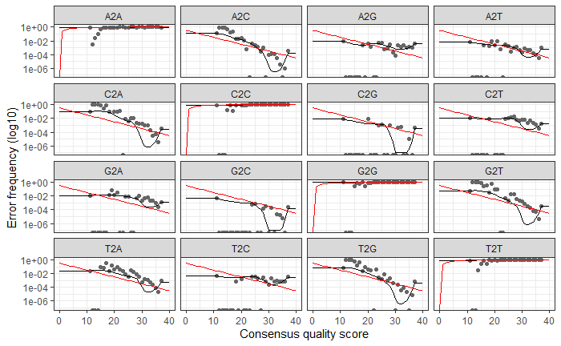

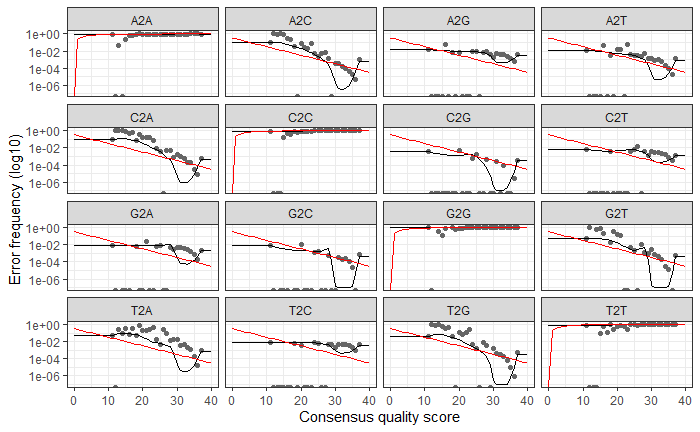

From the tutorial: Points are the observed error rates for each consensus quality score. The black line shows the estimated error rates after convergence of the machine-learning algorithm. The red line shows the error rates expected under the nominal definition of the Q-score.

### The DADA2 step

This is the core sample inference algorithm. DADA2 infers sample sequences exactly and resolves differences as little as 1 nucleotide. DADA2 identifies more real variants than other methods.

Sample inference and merger of paired-end reads:

```r
#set up place for mergers
mergers <- vector("list", length(sample.names))
names(mergers) <- sample.names

# Note: if this loop doesn't work, you've done something wrong. You've probably made an error earlier in the code, probably with the location of your forward and reverse reads and it's generated duplicate sample names
# Normal to get warning message that there are duplicate sequences

for(sam in sample.names) { #for each sample do the following:
  cat("Processing:", sam, "\n")
  derepF <- derepFastq(filtFs[[sam]]) #de-replicate forwards
  ddF <- dada(derepF, err=errF, multithread=TRUE) # core sample interference algorithm
  derepR <- derepFastq(filtRs[[sam]]) #de-repicate reverses
  ddR <- dada(derepR, err=errR, multithread=TRUE) # core sample interference algorithm
  merger <- mergePairs(ddF, derepF, ddR, derepR) # Merge paired end reads
  mergers[[sam]] <- merger
}
```

```
Processing: 326.D_S11
Sample 1 - 352785 reads in 80728 unique sequences.
Sample 1 - 352785 reads in 84037 unique sequences.
Processing: 327.D_S11
Sample 1 - 348760 reads in 87234 unique sequences.
Sample 1 - 348760 reads in 88117 unique sequences.
Processing: 356.D_S12
Sample 1 - 460160 reads in 65362 unique sequences.
Sample 1 - 460160 reads in 66185 unique sequences.
```

#### Some more filtering post-DADA2

|  | dada2_input | filtered | nonchim | final_perc_reads_retained |
| --- | --- | --- | --- | --- |
| 326.D_S11 | 380421 | 352785 | 310084 | 81.5 |
| 327.D_S11 | 380698 | 348760 | 310741 | 81.6 |
| 356.D_S12 | 496592 | 460160 | 407880 | 82.1 |

### Assign taxonomy using Silva reference database

The dada2 package GitHub maintains the most updated versions of the [Silva databases.](https://benjjneb.github.io/dada2/training.html). The versions in this GitHub repository, used here, were last updated on March 10, 2021.

```r
# Assign taxonomy based on silva reference database at genus level, you must have the appropriate Silva database downloaded and in the appropriate folder.

tax_silva <- assignTaxonomy(seqtab, "/Users/Swilliams/Documents/GitHub/microbes_pipeline/Dada2Silva/silva_nr99_v138.1_train_set.fa", multithread=FALSE)
```

[output not shown]